# Análisis del servicio de alojamiento de Airbnb en nueve ciudades de Europa del 2023

# Introducción

## Relevancia

La relevancia de nuestro proyecto radica que en la actualidad los servicios de Airbnb, representan una considerable oferta de alojamientos alrededor del mundo. Esta plataforma digital representa una gran acogida por muchos usuarios que desean alquilar un espacio a viajeros que buscan alojamiento, esto por la flexibilidad de precios en comparación con los hoteles.Es por ello que es importante realizar un análisis de en determinadas ciudades para conocer cómo funcionan los servicios de alojamiento en la actualidad.

## Objetivos

- Analizar las ciudades con mejor ranking de experiencia de Airbnb en Europa del 2023.
- Describir las características de los alojamientos más caros y más económicos en ciudades de Europa del 2023.
- Analizar la atracción de un Airbnb y su relación con su ubicación en ciudades de Europa del 2023.

## Contexto

Nuestro proyecto se centra realizar un análisis estadístico el servicio de un Airbnb, el cual se basa en que un propietario realiza un arrendamiento de corto plazo a cualquiera que busque alojamiento. Esta servicio puede ser contratado desde cualquier parte del mundo mediante una plataforma digital, en la cual los usuaarios podrán calificar, comentar en base a su experiencia sus niveles de satisfacción limpieza y etc.

## Planificación

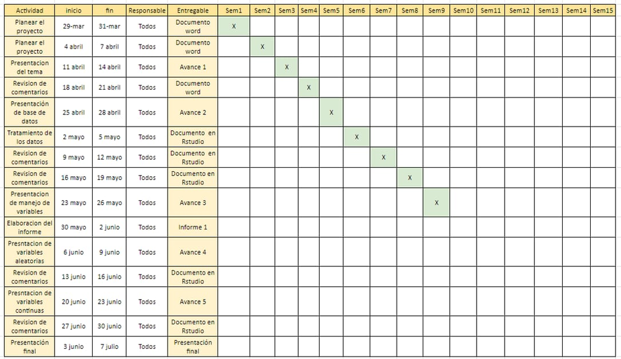

# Datos

## Proceso de recolección de datos

Para el proceso de recolección se realiza una búsqueda de base de datos de la siguiente página web https://www.kaggle.com/datasets/dipeshkhemani/airbnb-cleaned-europe-dataset?group=bookmarked. La elegida, es una fuente secundaria que tiene un total de 41714 observaciones y un total de 19 variables.

- Población

  La población del estudio son todos airbnb’s de nueve ciudades principales en Europa en el 2023.
- Unidad muestra

  La unidad muestra es cada airbnb (alojamiento) que se encuentra en funcionamiento en esas nueve ciudades en Europa. Muestreo El método de muestreo utilizado fue muestreo aleatorio simple.
- Tamaño de la muestra

  El tamaño de la muestra son 41714 alojamientos.

## Variables

[output not shown]

## Limpieza de datos

### Lectura de base de datos

```r
library(readr)
library(dplyr)
library(ggplot2)
D <- read_csv("Aemf1.csv") #EL ARCHIVO Aemf1 y datos.AIRBNB es lo mismo.
coef_var <- function(x, na.rm = FALSE) {sd(x, na.rm=na.rm) / mean(x, na.rm=na.rm)}


roundF <- function(x){return(round(x,digits = 2))}
```

```r
# Número de Observaciones y Variables
nrow(D)
ncol(D)
```

- Eliminamos la columna 18 y 16 (usamos sólo sus valores normalizados)

```r
View(D)

D$`Attraction Index` <- NULL
D$`Restraunt Index` <- NULL
```

- Re asignación de nombres :

```r
names(D)
```

```r
D %>% rename( Tipo = `Room Type` , Capacidad = `Person Capacity`, Oferta = Business, Habitaciones = Bedrooms, Ind.Atraccion = `Normalised Attraction Index`, Precio = Price, Share_Room = `Shared Room`, Limpieza = `Cleanliness Rating`, Ind.Restaurantes = `Normalised Restraunt Index`, Satisfaccion = `Guest Satisfaction`, Ciudad = City, Private_Room = `Private Room`, Distance_Center = `City Center (km)`, Distance_Metro = `Metro Distance (km)`) -> D2

View(D2)
```

```r
names(D2)
```

- Búsqueda de NA y comprobación de casos completos

```r
Total_de_NAs <- sum(is.na(D))
print(paste("El total de NAs es :", Total_de_NAs))

Observaciones_completas <- sum(complete.cases(D2))
print(paste("Observaciones completas es : ",Observaciones_completas ))
Observaciones_incompletas <- sum(!complete.cases(D2))
print(paste("Observaciones incompletas es : ", Observaciones_incompletas))
```

- Para la limpieza de datos se tiene encuenta lo siguiente:

#### Verificar Variables booleanas

```r
# El primer paso para la limpieza de datos es hacer un resumen de los datos que se tienen.
summary(D2)
```

- **Multiple Rooms, Shared Room, Private Room y Oferta :** En primer lugar, se observa que Multiple rooms tiene como valor mínimo 0 y como valor máximo 1; esto mismo ocurre en el caso de la variable Oferta. Procedemos a analizar qué valores se encuentran dentro de estas dos variables.

```r
par(mfrow=c(1,2))

counts <- table(D2$`Multiple Rooms`)
barplot(counts, main = "Multiple Rooms", ylab = "Número de Observaciones", xlab = "Valores" , ylim = c(0,35000))
```

```r
counts <- table(D2$Oferta)
barplot(counts, main = "Oferta", ylab = "Número de Observaciones", xlab = "Valores" , ylim = c(0,30000), xlim = c(0,2) )
#Como se observa, ambas variables cuentan solamente con "0" y "1" como valores, por lo que se trata de variables booleanas. Se observa que, además de estas dos variables, se tiene que Share_Room, Private_Room y Superhost también son variables de tipo bool. Para facilitar las operaciones futuras, se procederá a cambiar los "0" y "False" a la cadena "No", y los "1" y "True" a la cadena "Sí".
```

```r
vec <- factor(D2$Oferta, labels = c('No','Sí'))
D2$Oferta <- vec
vec <- factor(D2$`Multiple Rooms`, labels = c('No','Sí'))
D2$`Multiple Rooms` <- vec
vec <- factor(D2$Share_Room, labels = c('No','Sí'))
D2$Share_Room <- vec
vec <- factor(D2$Private_Room, labels = c('No','Sí'))
D2$Private_Room <- vec
vec <- factor(D2$Superhost, labels = c('No','Sí'))
D2$Superhost <- vec
```

#### Verificar variables númericas enteras:

- **Capacidad y Habitaciones :** Se verifica que Capacidad contenga solamente números enteros.El mismo análisis se realizará para la variable Habitaciones.

```r
par(mfrow=c(1,2))
counts <- table(D2$Capacidad)
barplot(counts, main = "Capacidad", ylab = "Número de Observaciones", xlab = "Valores" , ylim = c(0,20000))
counts <- table(D2$Habitaciones)
barplot(counts, main = "Habitaciones", ylab = "Número de Observaciones", xlab = "Valores" , ylim = c(0,30000))
```

Se observa que la variable habitaciones tiene casos con valor 0. A continuación se analizarán estos casos; para ello, se filtrarán las filas que tienen 0 habitaciones.

```r
filter(D2, Habitaciones==0)
```

Se observa que no hay ningún patrón o algo que indique por qué estos airbnb tienen 0 habitaciones. Como no se tiene evidencia para sustentar que un airbnb pueda tener 0 habitaciones, se procederá a colocar NA’s en las filas donde se encuentran los airbnb con 0 habitaciones.

```r
D2$Habitaciones <- replace(D2$Habitaciones, D2$Habitaciones==0, NA)
```

A continuación, se verificará que los valores de Habitaciones se hayan reemplazado correctamente.

```r
counts <- table(D2$Habitaciones)
barplot(counts, main = "Habitaciones", ylab = "Número de Observaciones", xlab = "Valores" , ylim = c(0,30000))
```

Limpieza y Satisfacción : son puntuaciones dejadas por los usuarios de los airbnb’s, son números enteros.

```r
counts <- table(D2$Limpieza)
barplot(counts, main = "Limpieza", ylab = "Número de Observaciones", xlab = "Valores" , ylim = c(0,20000))
```

```r
table(D2$Satisfaccion)
```

Se observa que la variable Limpieza tiene solamente números enteros en el rango 2-10 y la variable Satisfacción también, entre 20-100.

#### Verificar variables númericas no enteras

- **Precio, City Center, Metro distance , Attraction y Restaurants Normalized :** se observa que el Indice de Atracción normalizado y el Índice de Restaurantes normalizado se encuentran dentro (0-100). También se tienen a las variables Precio, City Center y Metro Distance. Se observa que los valores máximos se alejan considerablemente de la media. Por este motivo, se procederá a analizar cada una de estas variables.

```r
plot(D2$Precio, xlab= "Airbnb's" , ylab = "Precio")
```

Se observa que hay muy pocos casos por encima de 10000 dólares, a continuación se filtrará las filas que tienen un precio mayor a 10000 USD.

```r
filter(D2, Precio>10000)
```

Después de revisar los datos actuales en Airbnb a través de su aplicación, se encontró que, actualmente, hay 405 alojamientos en Atenas, más de 1000 en París, 168 en Vienna que tienen precios por encima de los 10000 USD. Por este motivo, estos datos se continuarán considerando dentro del dataset.

A continuación se analiza la variable Distance_Center, que representa la distancia al centro de del airbnb.

```r
plot(D2$Distance_Center, xlab= "Airbnb's" , ylab = "Distance to City Center (km)")
```

Se observa que son pocos los airbnb’s que tienen una distancia al centro por encima de 15 Km, se procederá a filtrar las filas según esta condición.

```r
filter(D2, Distance_Center>15)
```

A continuación se analizarán en qué ciudades se encuentran estos airbnb’s.

```r
unique(filter(D2, Distance_Center>15)[,'Ciudad'])
```

Se observa que estos airbnb’s se ubican en Berlin o Budapest. El área de estas ciudades es de 891.2 km<sup>2</sup> y 525.2 km<sup>2</sup>, respectivamente. Debido a esto, es posible que existan airbnb’s que se encuentren a 15 km o más de distancia del centro.

A continuación se analizará la variable Distance_Metro, que representa la distancia a la estación de metro más cercana al airbnb.

```r
plot(D2$Distance_Metro, xlab= "Airbnb's" , ylab = "Distance to Metro Station (km)")
```

Se filtrarán los airbnb’s con distancia mayor a 8km, ya que se observa que no son muchos en la gráfica.

```r
filter(D2, Distance_Metro>8)
```

A continuación se analizarán en qué ciudades se encuentran estos airbnb’s.

```r
unique(filter(D2, Distance_Metro>8)[,'Ciudad'])
```

Nuevamente, se observa que las ciudades son Berlín y Budapest, que son ciudades bastante grandes como se mencionó en el punto anterior. Por este motivo, se considerarán como datos válidos.

#### Verificando variables de tipo character

Por último se procederá a analizar las variables Ciudad, Día y Tipo; estas son catalogadas por R como variables de tipo char. Para el caso, de la variable Ciudad, deberían haber 9 valores distintos, que representen las 9 ciudades a las que pertenece la data.

```r
unique(D2$Ciudad)
unique(D2$Tipo)
unique(D2$Day)
counts <- table(D2$Ciudad)
barplot(counts, main = "Ciudad", ylab = "Número de Observaciones" , las=2, ylim = c(0,10000), cex.names = 0.9)
```

Día y Tipo

```r
par(mfrow=c(1,2)) #QUE HACE mfrow ?
counts <- table(D2$Day)
barplot(counts, main = "Día", ylab = "Número de Observaciones", las = 2, ylim = c(0,25000), cex.axis = 0.8, cex.lab = 0.7, cex.names = 0.6)
counts <- table(D2$Tipo)
barplot(counts, main = "Tipo", ylab = "Número de Observaciones", las = 2, ylim = c(0,30000), cex.axis = 0.8, cex.names = 0.6, cex.lab = 0.7)
```

No hay anomalías, y concluímos que nuestra data se encuentra en condiciones adecuadas para análisis posteriores.

# Análisis descriptivo

### 1. Análisis Univariado :

```r
#SATISFACCIÓN

table(D2$Satisfaccion)
```

```r
which.max(table(D2$Satisfaccion))
which.min(table(D2$Satisfaccion))
```

```r
## LIMPIEZA
table(D2$Limpieza)
```

```r
which.max(table(D2$Limpieza))
which.min(table(D2$Limpieza))
```

En el caso de la variable limpieza, se observa que los 3 valores más seleccionados son 8, 9 y 10; en ese orden. El valor menos seleccionado por los usuarios es el de 3.

```r
## ATRACCIÓN

mean_atraccion <- mean(D2$Ind.Atraccion)
median_atraccion <- median(D2$Ind.Atraccion)
par(mfrow=c(1,2)) #QUE HACE mfrow ?
boxplot(D2$Ind.Atraccion, main = "Atracción", xlab = "Índice de Atracción", ylab = "Frecuencia")
# Add mean as a red point
points(mean_atraccion, col = "red", pch = 16)
# Add median as a blue point
points(median_atraccion, col = "blue", pch = 16)
hist(D2$Ind.Atraccion, main = "Atracción", xlab = "Índice de Atracción", ylab = "Frecuencia")
# Add mean as a red dashed line
abline(v = mean_atraccion, col = "red", lwd = 2)
# Add median as a blue dashed line
abline(v = median_atraccion, col = "blue", lwd = 2)
```

```r
mean_atraccion
median_atraccion
IQR(D2$Ind.Atraccion)
quantile(D2$Ind.Atraccion)
```

ANÁLISIS : El índice de atracción toma valores del 1 al 100. En las gráficas se puede observar que la mayoría de valores se encuentran por debajo de 20, y que la media y la mediana son valores cercanos a 10. En los valores obtenidos se aprecia que más del 50% de los datos es menor a 10 y el 75% de los datos son menores a 15.47. Con esta información, se puede afirmar que la mayoría de valores son bajos para el índice de atracción.Asimismo, la media es mayor a la mediana por lo que está sesgado a la derecha e indica que hay menos alojamientos con un índice de satisfacción alta entre 60 a 100.

```r
##Precio
mean_precio<- mean(D2$Precio)
median_precio <- median(D2$Precio)
par(mfrow=c(1,2))
boxplot(D2$Precio, main = "Precio de habitaciones en Airbnb", xlab = "Precio", ylab = "Frecuencia")
# Add mean as a red point
points(mean_precio, col = "red", pch = 16)
# Add median as a blue point
points(median_precio, col = "blue", pch = 16)
hist(D2$Precio, main = "Precio de habitaciones en Airbnb", xlab = "Precio", ylab = "Frecuencia")
# Add mean as a red dashed line
abline(v = mean_precio, col = "red", lwd = 2)
# Add median as a blue dashed line
abline(v = median_precio, col = "blue", lwd = 2)
```

```r
mean_precio
median_precio
IQR(D2$Precio)
quantile(D2$Precio)
```

```r
##Tipo

ggplot(data= D2, mapping=aes(x=Tipo))+ geom_bar()+ theme_grey()+ labs(title="Gráfica de tipos de habitaciones",x="Tipo",y="Frecuencias")
```

ANÁLISIS : El tipo de habitación que ofertan los airbnb son casas o apartamentos enteros, seguidos por las habitaciones privadas y en un menor porcentaje se ofertan habitaciones compartidas entre varios usuarios.

```r
#CAPACIDAD

mean_capacidad <- mean(D2$Capacidad)
median_capacidad <- median(D2$Capacidad)
par(mfrow=c(1,2))
boxplot(D2$Capacidad, main = "Capacidad", xlab = "Capacidad", ylab = "Frecuencia")
# Add mean as a red point
points(mean_capacidad, col = "red", pch = 16)
# Add median as a blue point
points(median_capacidad, col = "blue", pch = 16)
hist(D2$Capacidad, main = "Capacidad", xlab = "Capacidad", ylab = "Frecuencia")
# Add mean as a red dashed line
abline(v = mean_capacidad, col = "red", lwd = 2)
# Add median as a blue dashed line
abline(v = median_capacidad, col = "blue", lwd = 2)
```

```r
mean_capacidad
median_capacidad
IQR(D2$Capacidad)
quantile(D2$Capacidad)
```

```r
#MULTIPLE ROOM

ggplot(data= D2, mapping=aes(x=`Multiple Rooms`))+ geom_bar()+ theme_grey()+ labs(title="Gráfica de habitaciones múltiples",x="Tipo",y="Frecuencias")
```

```r
##OFERTA
ggplot(data= D2, mapping=aes(x=Oferta))+ geom_bar()+ theme_grey()+ labs(title="Gráfica de Oferta",x="Ofertas",y="Frecuencias")
```

```r
##Habitaciones
mean_habitaciones <- mean(D2$Habitaciones,na.rm = TRUE)
median_habitaciones <- median(D2$Habitaciones,na.rm=TRUE)
par(mfrow=c(1,2))
boxplot(D2$Habitaciones, main = "Número de habitaciones", xlab = "Habitaciones", ylab = "Frecuencia")
# Add mean as a red point
points(mean_habitaciones, col = "red", pch = 16)
# Add median as a blue point
points(median_habitaciones, col = "blue", pch = 16)
hist(D2$Habitaciones, main = "Número de habitaciones", xlab = "Habitaciones", ylab = "Frecuencia")
# Add mean as a red dashed line
abline(v = mean_habitaciones, col = "red", lwd = 2)
# Add median as a blue dashed line
abline(v = median_habitaciones, col = "blue", lwd = 2)
```

```r
mean_habitaciones
median_habitaciones
IQR(D2$Habitaciones, na.rm=TRUE)
quantile(D2$Habitaciones,na.rm=TRUE)
```

ANÁLISIS : Se observa que la mayor parte de airbnb’s cuenta con una sola habitación.

```r
##DISTANCE CENTER
mean_distC <- mean(D2$Distance_Center)
median_distC <- median(D2$Distance_Center)
par(mfrow=c(1,2))
boxplot(D2$Distance_Center, main = "Distance center", xlab = "Distance Center", ylab = "Frecuencia")
# Add mean as a red point
points(mean_distC, col = "red", pch = 16)
# Add median as a blue point
points(median_distC, col = "blue", pch = 16)
hist(D2$Distance_Center, main = "Distance Center", xlab = "Distance Center", ylab = "Frecuencia")
# Add mean as a red dashed line
abline(v = mean_distC, col = "red", lwd = 2)
# Add median as a blue dashed line
abline(v = median_distC, col = "blue", lwd = 2)
```

```r
mean_distC
median_distC
IQR(D2$Distance_Center)
quantile(D2$Distance_Center)
```

```r
##DISTANCE METRO

mean_distM <- mean(D2$Distance_Metro)
median_distM <- median(D2$Distance_Metro)
par(mfrow=c(1,2))
boxplot(D2$Distance_Metro, main = "Distance Metro", xlab = "Distance Metro", ylab = "Frecuencia")
# Add mean as a red point
points(mean_distM, col = "red", pch = 16)
# Add median as a blue point
points(median_distM, col = "blue", pch = 16)
hist(D2$Distance_Metro, main = "Distance Metro", xlab = "Distance Metro", ylab = "Frecuencia")
# Add mean as a red dashed line
abline(v = mean_distM, col = "red", lwd = 2)
# Add median as a blue dashed line
abline(v = median_distM, col = "blue", lwd = 2)
```

```r
mean_distM
median_distM
IQR(D2$Distance_Metro)
quantile(D2$Distance_Metro)
```

```r
##Índice de restaurantes
mean_Ind.Restaurant <- mean(D2$Ind.Restaurantes)
median_Ind.Restaurant <- median(D2$Ind.Restaurantes)
par(mfrow=c(1,2))
boxplot(D2$Ind.Restaurantes, main = "Índice de Restaurantes", xlab = "Índice de Restaurantes", ylab = "Frecuencia")
# Add mean as a red point
points(mean_Ind.Restaurant, col = "red", pch = 16)
# Add median as a blue point
points(median_Ind.Restaurant, col = "blue", pch = 16)
hist(D2$Ind.Restaurantes, main = "Índice de Restaurantes", xlab = "Índice de Restaurantes", ylab = "Frecuencia")
# Add mean as a red dashed line
abline(v = mean_Ind.Restaurant, col = "red", lwd = 2)
# Add median as a blue dashed line
abline(v = median_Ind.Restaurant, col = "blue", lwd = 2)
```

```r
mean_Ind.Restaurant
median_Ind.Restaurant
IQR(D2$Ind.Restaurantes)
quantile(D2$Ind.Restaurantes)
```